# A4: Incarceration

### Variable Comparison Chart

I included this chart to compare Black and White Prison populations per 100,00 people (rates) in 2010 and visually display that data. Each dot represents a location from the data set and it is placed on the graph wherever its corresponding Black and White prison population rate is. In a perfect world, the dots on the plot would be in a straight proportionate line from the bottom left to the top right. However, you can see on this plot when you study the scale and positioning of each dot that a majority of the points indicate a higher x-value (Black prison population rate) than y-value (White prison population rate). The shallowness of this plots’ trend indicates a disparity in the number of incarcerated Black Americans in an overwhelming majority of the cities in this dataset.

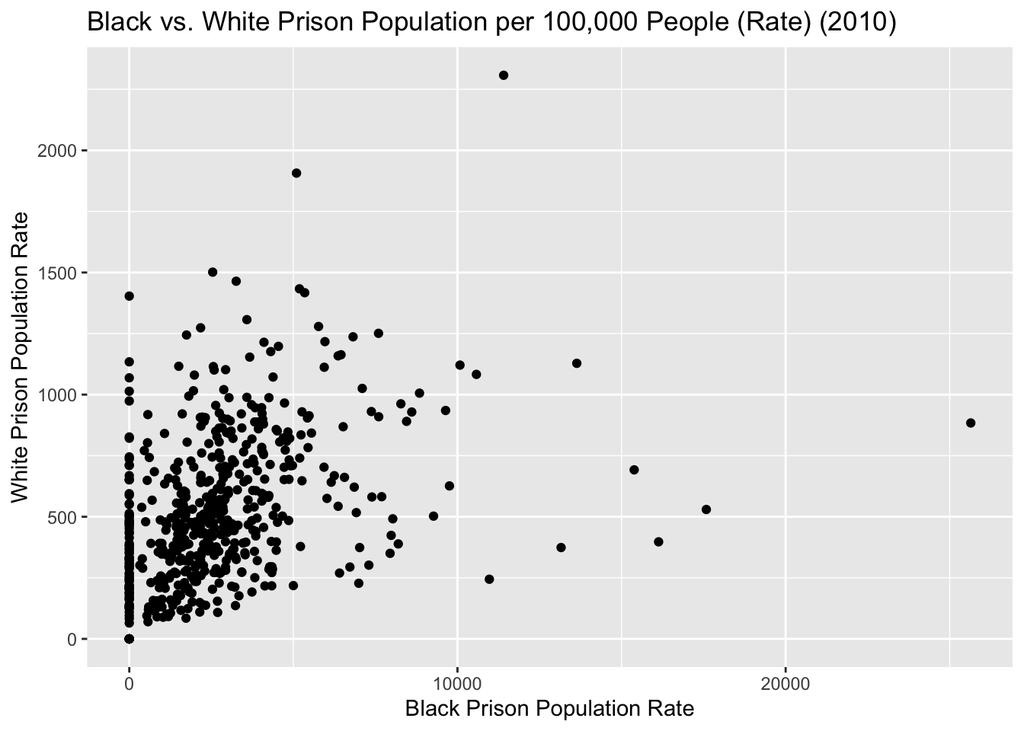

### Map

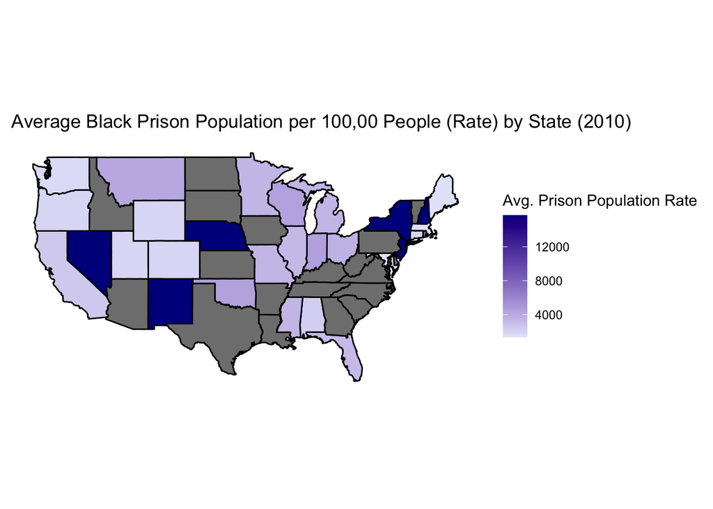